# Large Scale Linear Regression Models in Determination of Hourly Electricity Imbalance Sign

Nilüfer Çetin - Spring 2020

21 04 2021

## Problem

To effectively predict the hourly imbalance sign on a forecast setting of 1-day prior.

## Methodology

Forecasting the negative and positive imbalance amounts seperately to predict the actual imbalance amount and then state the sign of this as forecast.

## Forecasting the Hourly Positive Imbalance

### Training Model

To help identify which factors are important and dominating on a hourly level for these specific months/seasons of the year, data of 4 months from 2019 is gathered to be used as training set.

It is discovered that SMP (System Marginal Price) is able to cover a good amount of variability on Positive Imbalance. The worst performance is on Hour 17, with 0.39 R-squared value. For others performance change between 0.42 R- squared to 0.59. Hour 17,

```
##
## Call:
## lm(formula = Pos ~ Smf, data = all[Date <= "2019-05-31" & Date >=
##     "2019-02-01" & Hour == 17])
##
## Residuals:
##     Min      1Q  Median      3Q     Max
## -825.56 -297.17  -26.11  224.16  969.60
##
## Coefficients:
##              Estimate Std. Error t value Pr(>|t|)
## (Intercept) 1878.1054    96.9647  19.369  < 2e-16 ***
## Smf           -3.1307     0.3573  -8.762 1.66e-14 ***
## ---
## Signif. codes:  0 '***' 0.001 '**' 0.01 '*' 0.05 '.' 0.1 ' ' 1
##
## Residual standard error: 379.6 on 118 degrees of freedom
## Multiple R-squared:  0.3942, Adjusted R-squared:  0.389
## F-statistic: 76.77 on 1 and 118 DF,  p-value: 1.664e-14
```

After that, the difference in production, between the amount that is declared to be produced to EPIAS and the actual amount of hourly production is seen as important. However, this factor has shown to be important for hours between 0 (getting stronger after Hour 2) and till 19. Between 19 and 22, interestingly the difference in consumption, between the amount that is forecasted to be consumed and the actual amount of hourly consumption has replaced the place of production difference. Interestingly, Hour 23 does not seem to be affected by any of these and Hour 18 seem to be affected by both.

After these additions, the performance in the hours between 5 until 17 seem to be a lot improved with most above 0.65 and some even hitting 0.7 R-squared. Though the difference in consumption have improved the models between Hour 19-22, most reside on 0.5 R-squared. The worst performance is Hour 2 with 0.45 R-squared,

```
##
## Call:
## lm(formula = Pos ~ Smf + ProdDiff, data = all[Date <= "2019-05-31" &
##     Date >= "2019-02-01" & Hour == 2])
##
## Residuals:
##     Min      1Q  Median      3Q     Max
## -486.74 -160.14  -35.86  154.79  802.16
##
## Coefficients:
##               Estimate Std. Error t value Pr(>|t|)
## (Intercept) 1452.62842  113.19321  12.833  < 2e-16 ***
## Smf           -1.89957    0.36944  -5.142  1.1e-06 ***
## ProdDiff      -0.12518    0.06494  -1.927   0.0563 .
## ---
## Signif. codes:  0 '***' 0.001 '**' 0.01 '*' 0.05 '.' 0.1 ' ' 1
##
## Residual standard error: 239.2 on 117 degrees of freedom
## Multiple R-squared:  0.4611, Adjusted R-squared:  0.4519
## F-statistic: 50.05 on 2 and 117 DF,  p-value: < 2.2e-16
```

After that, checking for any possible relation between residuals and MCP (Market Clearing Price) seem to be reasonable in the light of evidence found by previous studies. Interestingly enough, MCP has proven to be effective in all months and hours except the duration of time between Hours 8-11.

MCP has been a good fit as a feature for the models but it did not capture a high amount of remaining variability in the residuals. After addition of MCP, R-squared of most Hours between 0-19 are higher than 0.55 and most of them close to 0.65. The improvements to the models after that point have become minimal and as a final strategy, the difference of production in Dams have been used as a regressor.

A surprising result is that the difference in production from Dams are only effective on evening in February and March. Hence, a second altered variable is added to these models.

After this point the worst performance is on Hour 17, with 0.56 R-squared. For most of the hours, the values are all above 0.65. Hour 17,

```
##
## Call:
## lm(formula = Pos ~ Smf + ProdDiff + Ptf, data = all[Date <= "2019-05-31" &
##     Date >= "2019-02-01" & Hour == 17])
##
## Residuals:
##     Min      1Q  Median      3Q     Max
## -655.35 -204.24  -41.34  196.04 1106.42
##
## Coefficients:
##               Estimate Std. Error t value Pr(>|t|)
## (Intercept) 1846.79798  124.28755  14.859  < 2e-16 ***
## Smf           -3.37249    0.68835  -4.899 3.15e-06 ***
## ProdDiff      -0.20206    0.06299  -3.208  0.00173 **
## Ptf            2.41286    0.54944   4.391 2.50e-05 ***
## ---
## Signif. codes:  0 '***' 0.001 '**' 0.01 '*' 0.05 '.' 0.1 ' ' 1
##
## Residual standard error: 320.1 on 116 degrees of freedom
## Multiple R-squared:  0.5766, Adjusted R-squared:  0.5657
## F-statistic: 52.66 on 3 and 116 DF,  p-value: < 2.2e-16
```

After these the models are,

Hours 0:7 and 12:13 -> SMP, MCP, Production Difference, Dam Production Difference

Hours 8:11 -> SMP, Production Difference

Hours 14:17 -> SMP, MCP, Production Difference

Hours 18 -> SMP, MCP, Production Difference, Consumption Difference

Hours 19:22 -> SMP, MCP, Consumption Difference, Altered Dam Production Difference

Hours 23 -> SMP, MCP, Altered Dam Production Difference

It should be noted that, the production amount from Dams, the difference in production from Wind and River and the total amount of production have also point out to be inline with the variability in only some of the models or in some seasons. To not complicate manners more and since the aim of the study is only to inspect the most prominent regressors rather than being able to guess the amount of positive imbalance correctly, these relations were ignored.

## Forecasting the Hourly Negative Imbalance

### Training Model

To help identify which factors are important and dominating on a hourly level for these specific months/seasons of the year, data of 4 months from 2019 is gathered to be used as training set.

It is found that the difference in production amount and the amount of production from Dams are important factors determining the hourly negative imbalance.

When these two predictors are added to the models, the R-squared values for models of hours after Hour 9 seem to be around 0.5. On night time, though these regressors are proven to be statistically significant the R-squared value is low with 0.26 at Hour 3 as the lowest,

```
##
## Call:
## lm(formula = Neg ~ ProdDiff + DamProd, data = all[Date >= "2019-02-01" &
##     Date <= "2019-05-31 " & Hour == 3])
##
## Residuals:
##     Min      1Q  Median      3Q     Max
## -762.29 -183.56   26.06  194.45  653.07
##
## Coefficients:
##              Estimate Std. Error t value Pr(>|t|)
## (Intercept) -57.34321  137.00751  -0.419 0.676319
## ProdDiff     -0.27831    0.04898  -5.682 9.92e-08 ***
## DamProd      -0.04258    0.01205  -3.533 0.000588 ***
## ---
## Signif. codes:  0 '***' 0.001 '**' 0.01 '*' 0.05 '.' 0.1 ' ' 1
##
## Residual standard error: 299.2 on 117 degrees of freedom
## Multiple R-squared:  0.2687, Adjusted R-squared:  0.2562
## F-statistic: 21.49 on 2 and 117 DF,  p-value: 1.121e-08
```

After some trial, error and with the help of evidence from previous studies, it is observed that SMP and MCP are also important in determining the amount of negative hourly imbalance.

With these addition for most of the hours the R-squared have reached 0.5. The best performances are reached around mid-day with R-squared values roughly 0.7. The performance in night time is still worse as the model of Hour 2 give 0.45 R-squared,

```
##
## Call:
## lm(formula = Neg ~ ProdDiff + DamProd + Smf + Ptf, data = all[Date >=
##     "2019-02-01" & Date <= "2019-05-31 " & Hour == 2])
##
## Residuals:
##     Min      1Q  Median      3Q     Max
## -719.09 -128.85   -6.01  158.90  610.94
##
## Coefficients:
##               Estimate Std. Error t value Pr(>|t|)
## (Intercept) -2.415e+02  1.340e+02  -1.802   0.0741 .
## ProdDiff    -1.559e-01  6.769e-02  -2.303   0.0231 *
## DamProd     -4.515e-02  9.708e-03  -4.651 8.89e-06 ***
## Smf         -2.139e+00  4.479e-01  -4.775 5.34e-06 ***
## Ptf          1.873e+00  4.239e-01   4.419 2.25e-05 ***
## ---
## Signif. codes:  0 '***' 0.001 '**' 0.01 '*' 0.05 '.' 0.1 ' ' 1
##
## Residual standard error: 248.6 on 115 degrees of freedom
## Multiple R-squared:  0.4633, Adjusted R-squared:  0.4446
## F-statistic: 24.82 on 4 and 115 DF,  p-value: 7.97e-15
```

Finally, the difference in production of wind turbines between the declared and observed have also realized as a factor determining the amount of hourly negative imbalance.

Once this is added as a final regressor, the model for negative imbalance is complete. R-squared values reach 0.5 for all hours and for most of them it is above 0.65.

After these the model is the same for all hours as,

MCP, SMP, Production Difference, Wind Production Difference, Dam Production Amount

## Testing the Models with Sliding Window Technique

With evidence from 2019 data, the regressors in the 48 models are determined. The next step is to test these claims on some test set as if in a forecasting setting.

To help this purpose, relevant data from Spring 2018, 2019, 2020 and March 2021 have been gathered. Observations from February, March and April 2018 have been used as solely train period and the rest of the observations have been forecasted with data up to 24-hours prior. That is to say, the models are updated with new daily observations and forecast for the next day is constructed via a model that has train data up to today.

Positive and Negative imbalance amounts have been forecasted separately. Before delving into accuracy statistics, it should also be useful to have a prior understanding of residuals of models. For positive imbalance amount the residuals have been observed as,

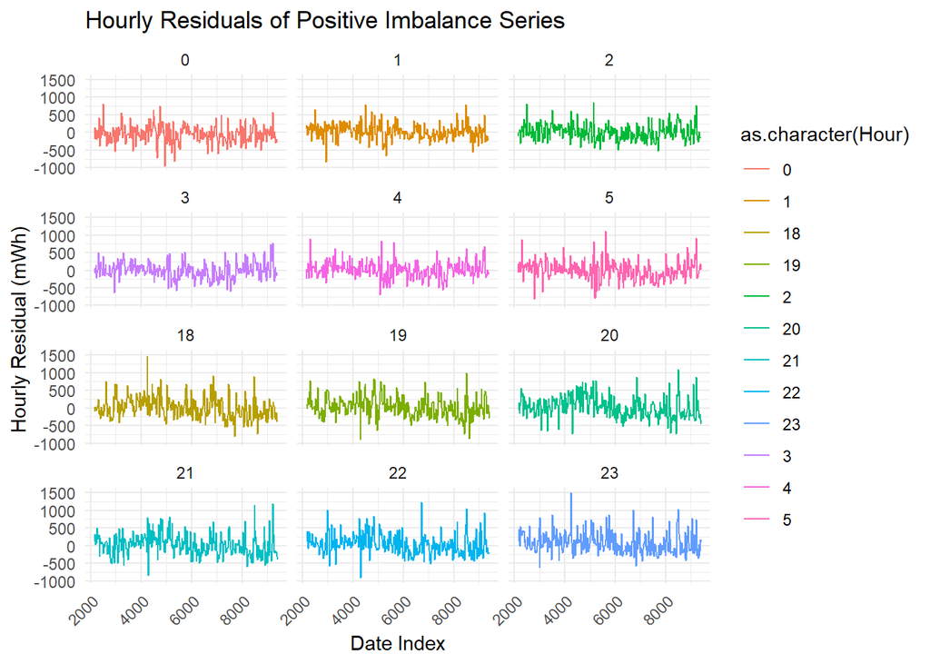

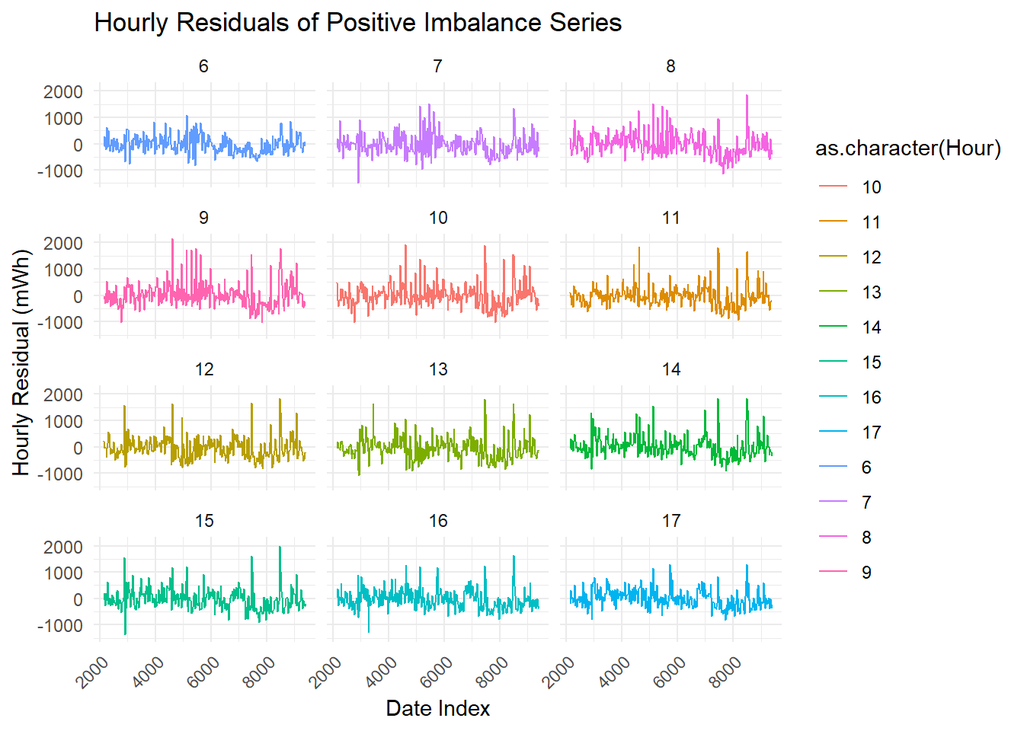

It can be seen that there are mostly problems with morning hours in some seasons. These can be analyzed in a further study. Most of the residual series for hours in night time resemble just a white noise.

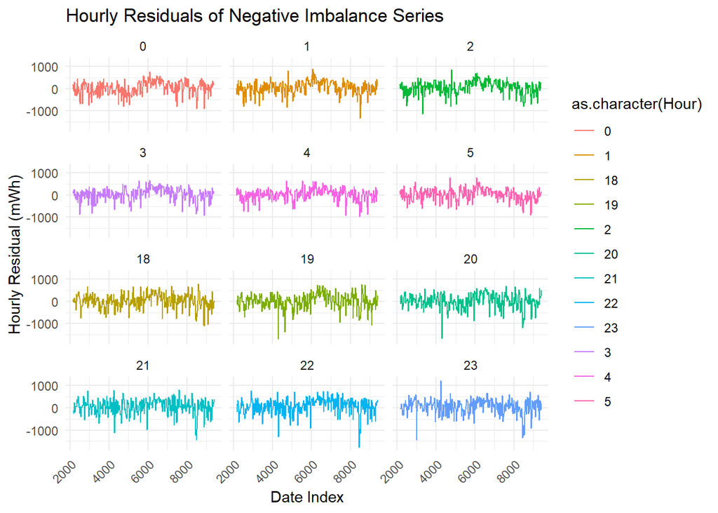

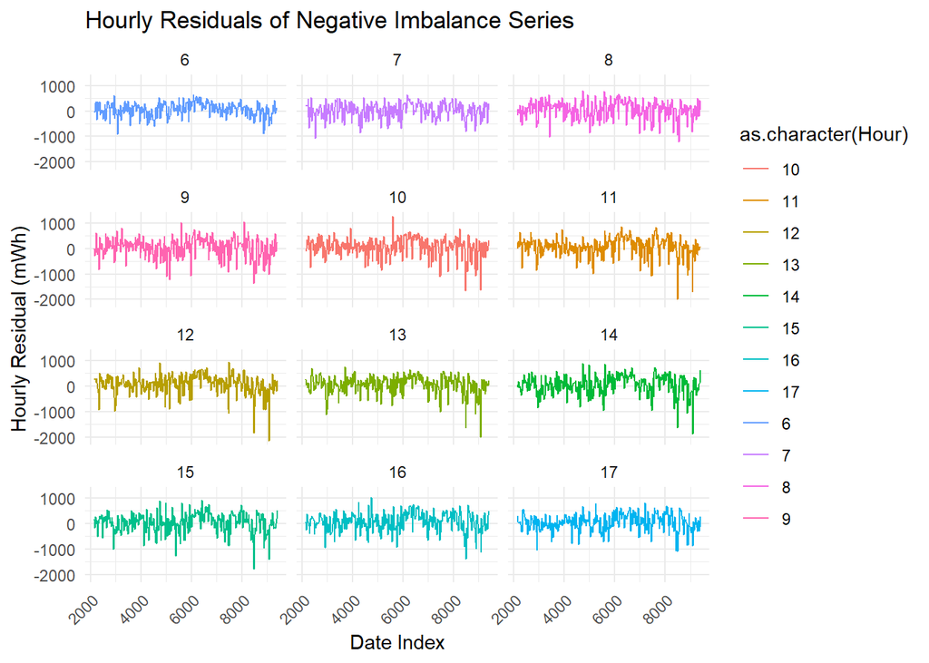

As can be seen, the results are similar from the perspective of hourly behaviors. However, it can also be observed that the models predicting negative imbalance amount have generalized better compared to those that are predicting positive imbalance amount.

When average residuals for negative and positive predictions are visualized in line plots with time,

```
##     Year Month     MeanPos    MeanNeg
##  1: 2018     5  -27.690625  42.656238
##  2: 2019     2   83.664066  -5.171916
##  3: 2019     3   79.063917  50.870414
##  4: 2019     4   92.005423 -12.906557
##  5: 2019     5   43.466700 -43.054142
##  6: 2020     2  -20.821788 257.217451
##  7: 2020     3    5.524903 175.166921
##  8: 2020     4 -176.735809  58.605452
##  9: 2020     5  -57.998651 -44.407332
## 10: 2021     3  -12.184987 -79.748165
```

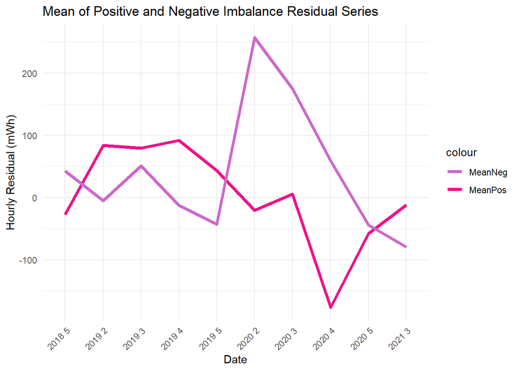

In year 2020 there seems some problematic behavior in both measures. This can be related to COVID period. There should also be an inspection for the absolute value of residuals,

```
##     Year Month  MeanPos  MeanNeg
##  1: 2018     5 190.6719 207.2234
##  2: 2019     2 260.8460 242.0547
##  3: 2019     3 195.0835 211.1681
##  4: 2019     4 275.7214 240.7456
##  5: 2019     5 300.8776 263.2250
##  6: 2020     2 189.9548 331.0928
##  7: 2020     3 228.8484 282.5308
##  8: 2020     4 333.0037 271.4282
##  9: 2020     5 326.6108 320.2742
## 10: 2021     3 240.2873 268.0201
```

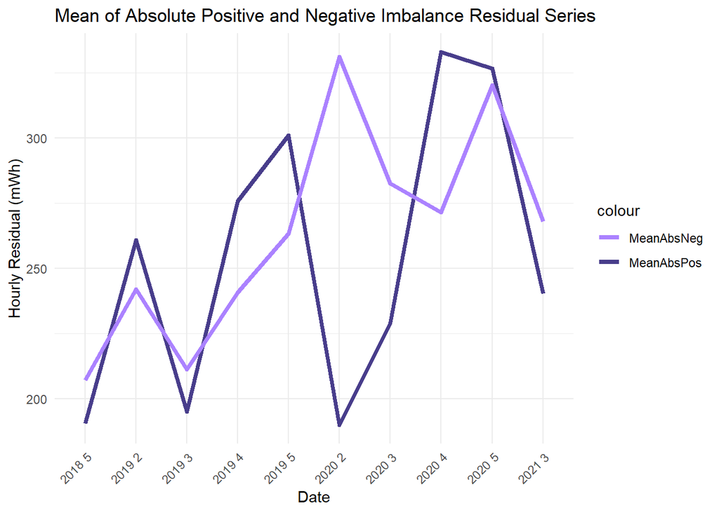

When similar results are also illustrated in a hourly manner,

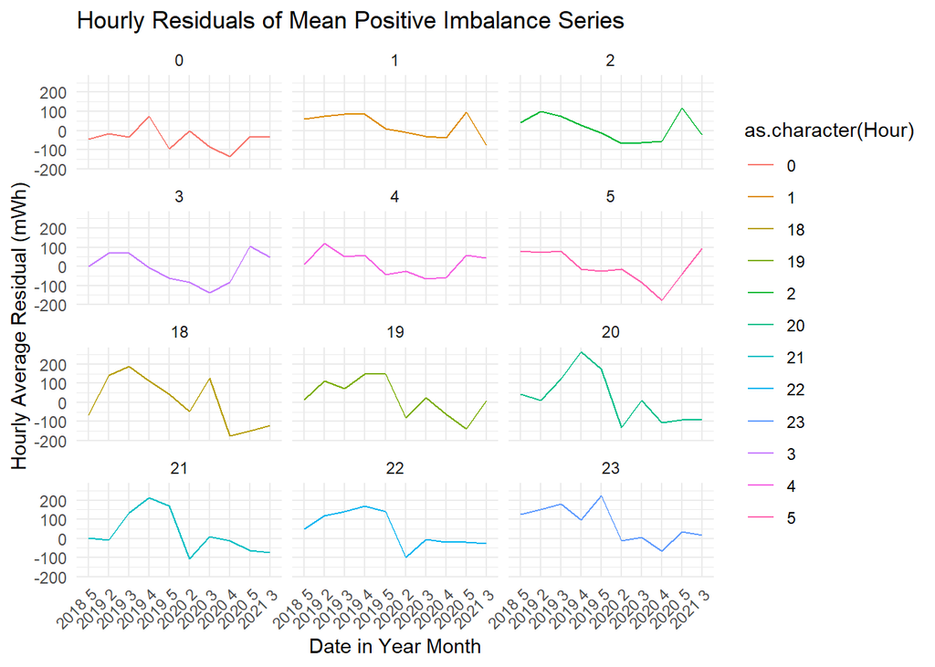

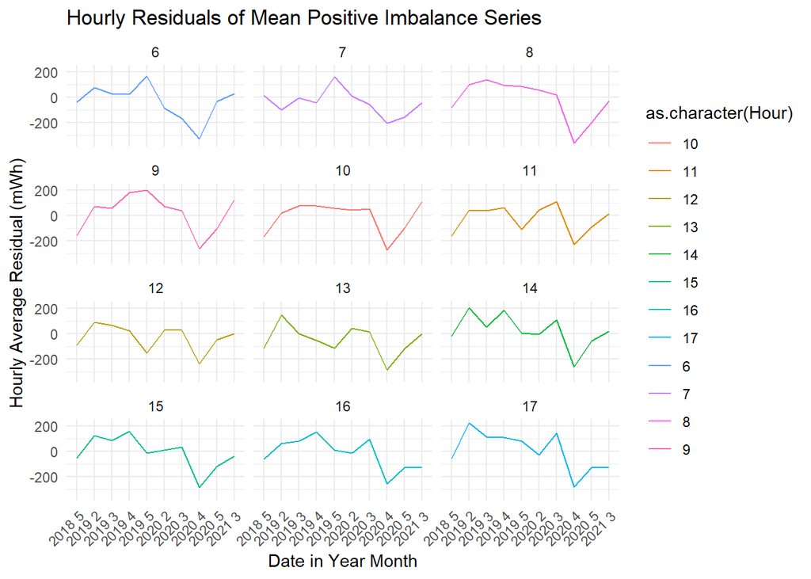

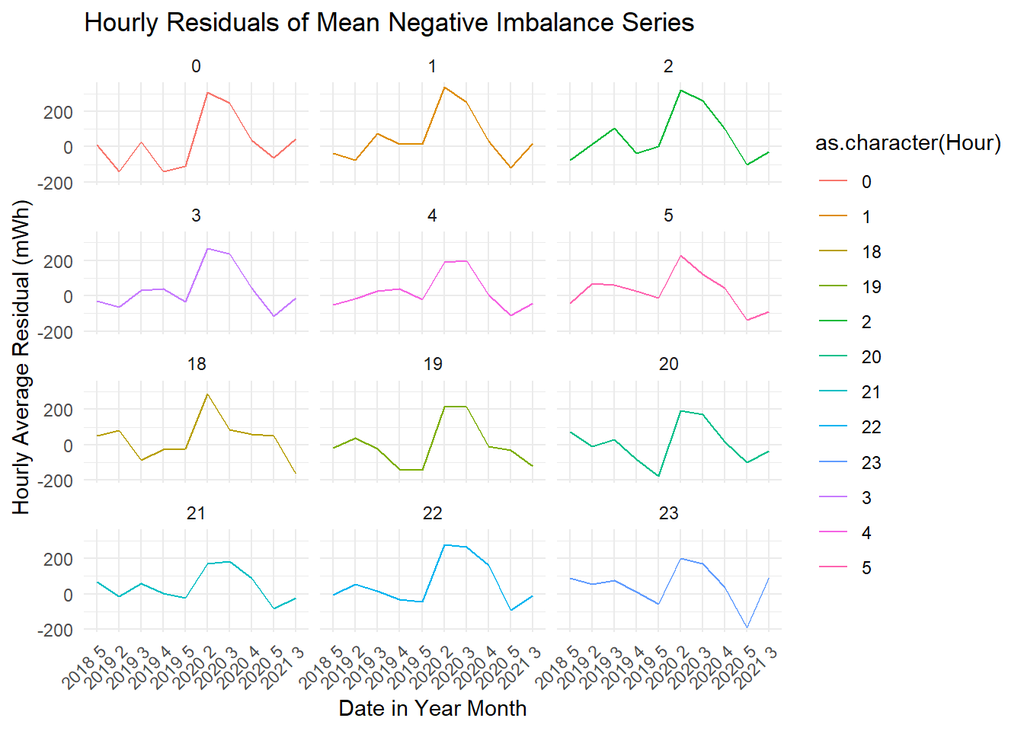

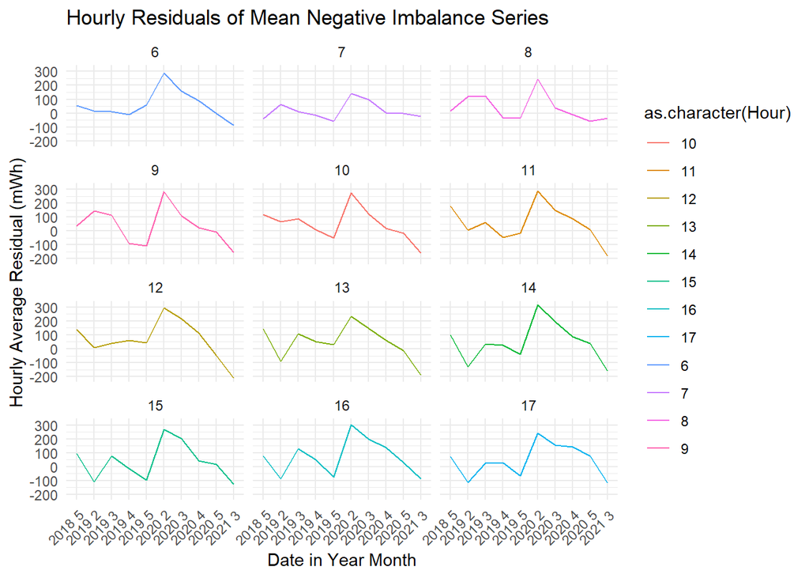

The same behaviors pointed in the overall graphs seem to persist in those specific time phrased graphs.

### Sign Forecasts and Accuracy Calculations

Once predicted with these models, the forecasts are summed to calculate the sign of the hourly imbalance. This shows an accuracy of,

```
## [1] 0.8947296
```

To see a more detailed illustration with a confusion matrix,

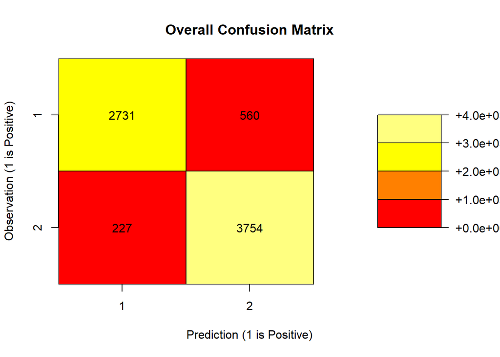

It can be seen that the most possible mistake is to guess a negative imbalance direction for a hour which is on positive direction. A possible way to tune the accuracy, specitivity and sensitivity is to change the threshold on deciding the sign of the final guess. To help reader illustrate different scenarios with various threshold values a density plot can be visualized,

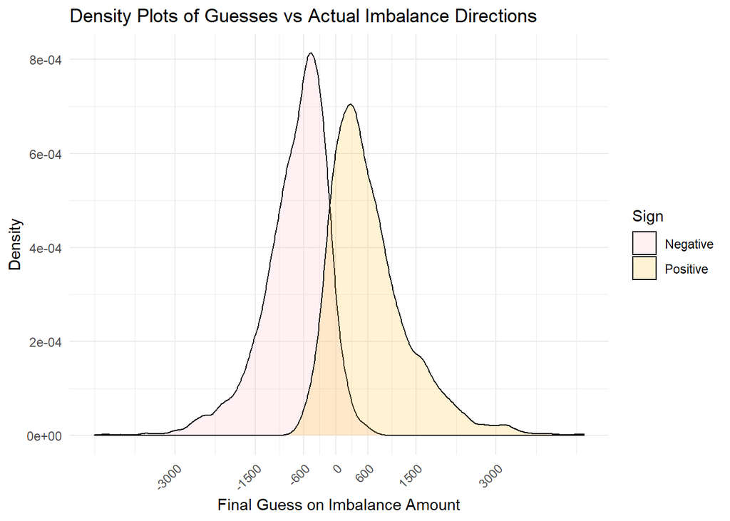

There is actually a wide interval of thresholds between -600 and 600, When same phonemana is visualized on a hourly basis,

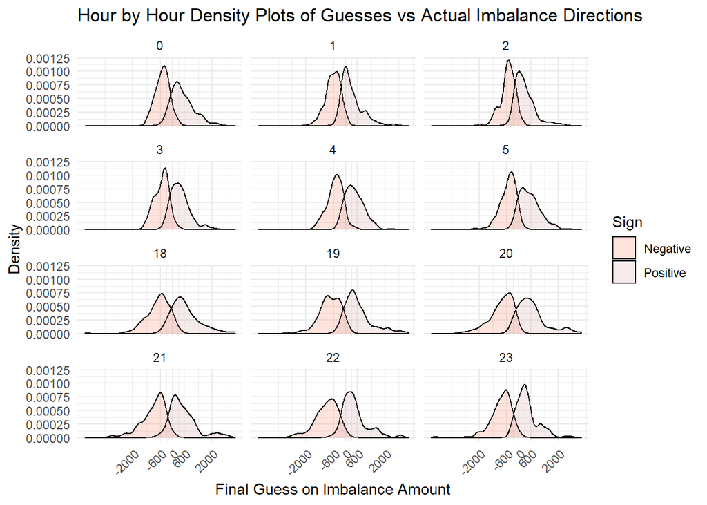

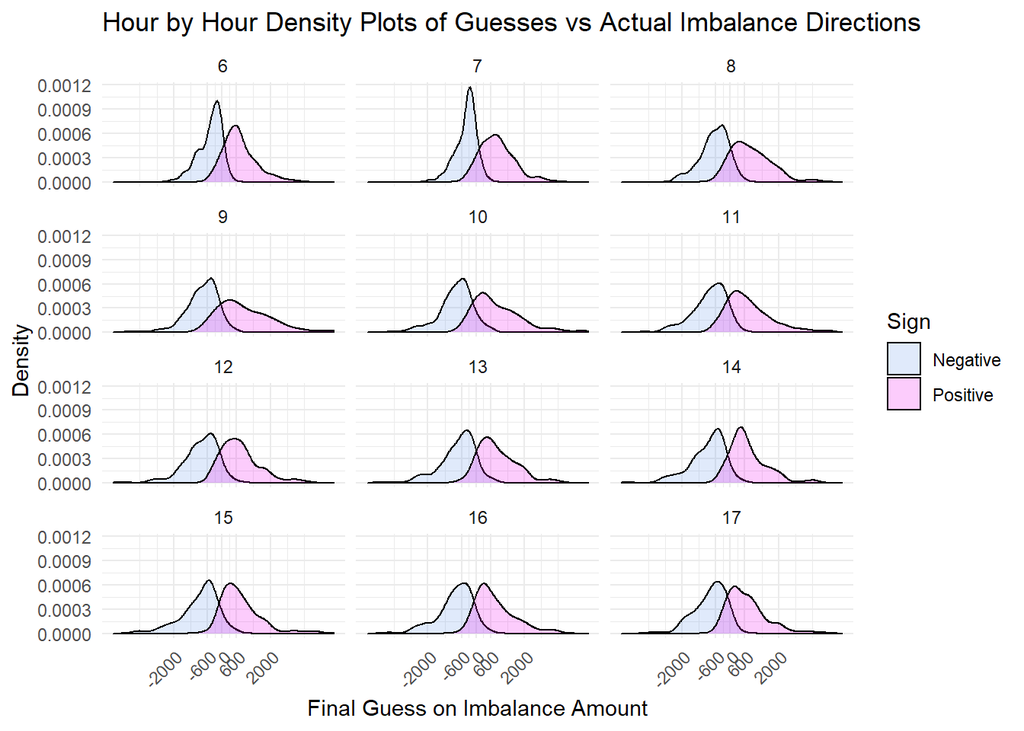

When overall hourly accuracy in prediction of the imbalance sign is illustrated,

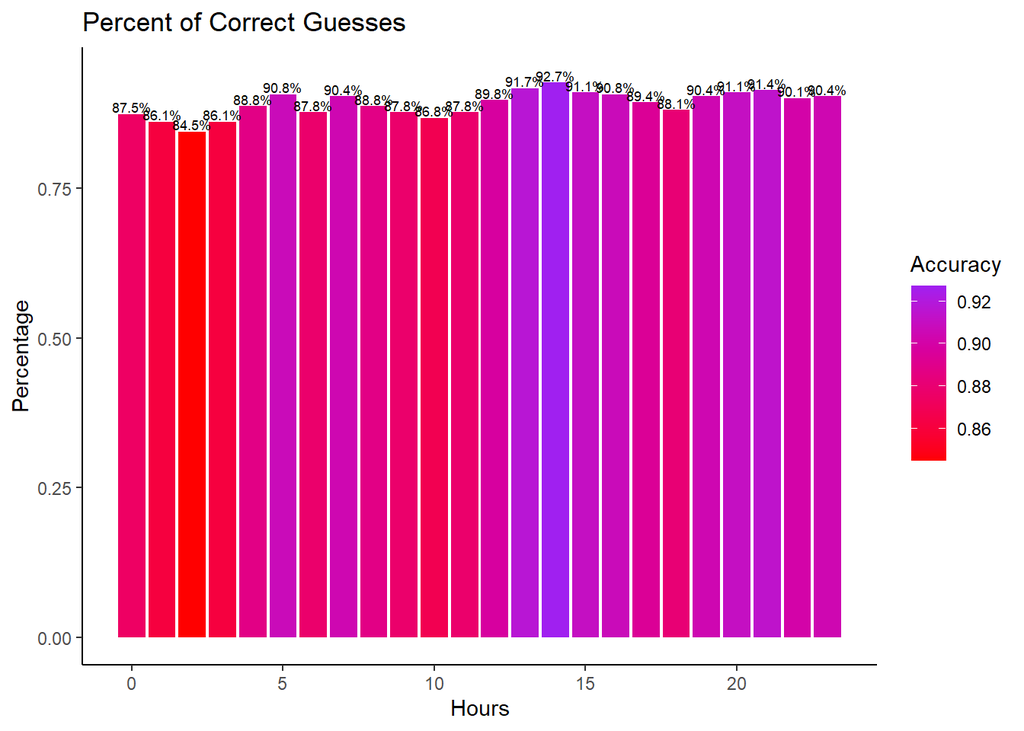

It is obvious that in general the hourly performances are similar so that it can be said on average the models perform similarly with not much outliers or extreme behavior. When overall monthly accuracy in prediction of imbalance direction is illustrated,

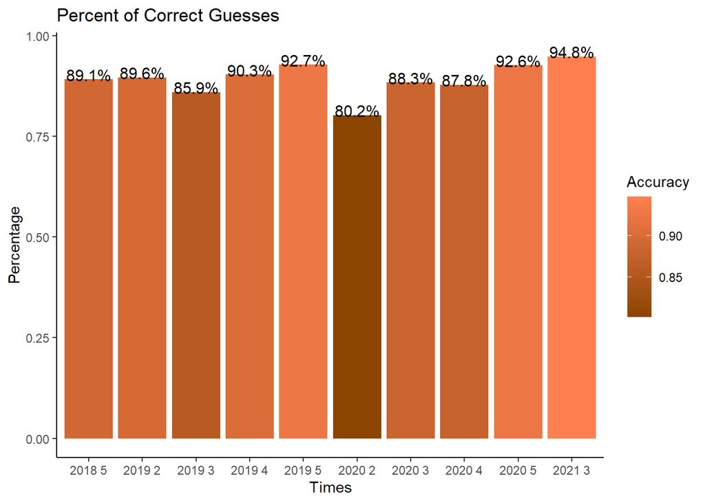

It is obvious that the performances are similar. However, there seems some deviations in February 2020. This might be because of the increased residual in determining the negative amount of imbalance on that month. When checked closely, most of the inaccurate guesses in that month have occurred in the hours with positive imbalance sign. Hence, it is highly probable that the models have overshooted the negative amount of imbalance in February 2020.

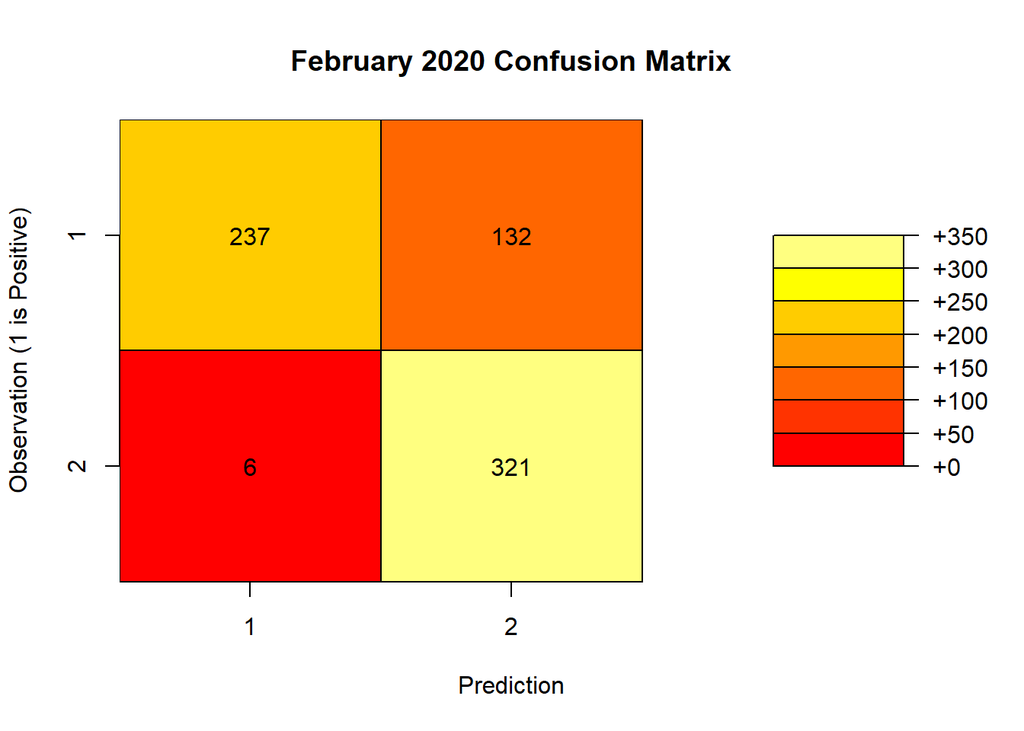

This confusion matrix proves that our claim is true.

## Final Residual Analysis

```
##     Hour   category       Cor
##  1:   18        Smf 0.2337383
##  2:   22   ConsDiff 0.2425395
##  3:    0 Production 0.2652874
##  4:   19        Smf 0.2676763
##  5:   11   WindDiff 0.2701075
##  6:   17   ProdDiff 0.2734907
##  7:    5 Production 0.2762508
##  8:   21        Smf 0.2779900
##  9:    0        Smf 0.2794712
## 10:    1   ProdDiff 0.2871386
## 11:    0    DamDiff 0.2929814
## 12:   20   ProdDiff 0.3133184
## 13:   18   ProdDiff 0.3241799
## 14:    8 Production 0.3537868
## 15:   20        Smf 0.3745646
## 16:    0   ProdDiff 0.4111204
```